# IR Spectroscopy Case Study

Predicting the protein content of meat samples

# Introduction

*Details herein on IR spectroscopy and the Tecator data are adapted from [Kuhn and Johnson (2013)](http://appliedpredictivemodeling.com/):*

Infrared (IR) spectroscopy technology is used to determine the chemical makeup of a substance. The theory of IR spectroscopy holds that unique molecular structures absorb IR frequencies differently. In practice a spectrometer fires a series of IR frequencies into a sample material, and the device measures the absorbance of the sample at each individual frequency. This series of measurements creates a spectrum profile which can then be used to determine the chemical makeup of the sample material. A Tecator Infratec Food and Feed Analyzer instrument was used to analyze 215 samples of meat across 100 frequencies. A sample of these frequency profiles is displayed below. In addition to an IR profile, analytical chemistry determined the percent content of water, fat, and protein for each sample. If we can establish a predictive relationship between IR spectrum and protein content, then food scientists could predict a sample’s protein content with IR instead of using analytical chemistry. This would provide costs savings, since analytical chemistry is a more expensive, time-consuming process.

# EDA

There are three potential response variables, `fat`, `protein` and `water`. These are all measured as percentages. The distributions are below:

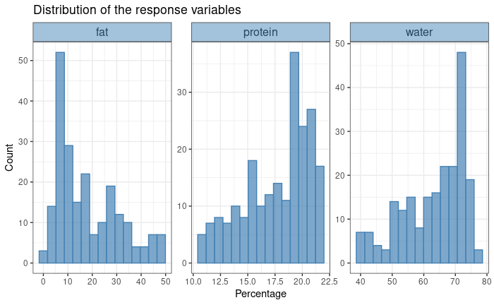

In this data the predictors are the measurements at individual frequencies (wavelengths ranging from 850–1050 nm). These absorbance spectra are plotted below. The full data set is on the left. On the right is a sample of 10 spectra with the associated protein percentage for that sample marked on the plot:

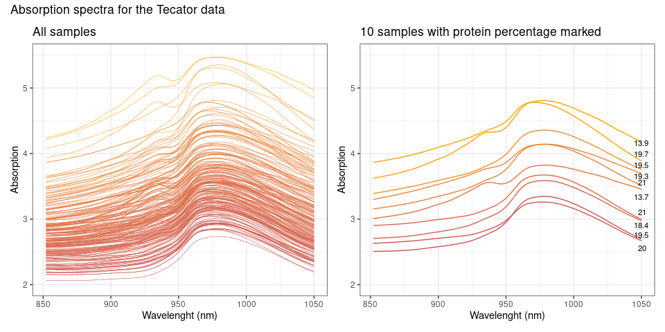

# PCA

Because the frequencies lie in a systematic order, the predictors have a high degree of correlation. Hence, the data lie in a smaller dimension than the total number of predictors. We can use PCA to determine the effective dimension of the data.

The below scree plots show that almost all of the variability in the data is explained by the first few components:

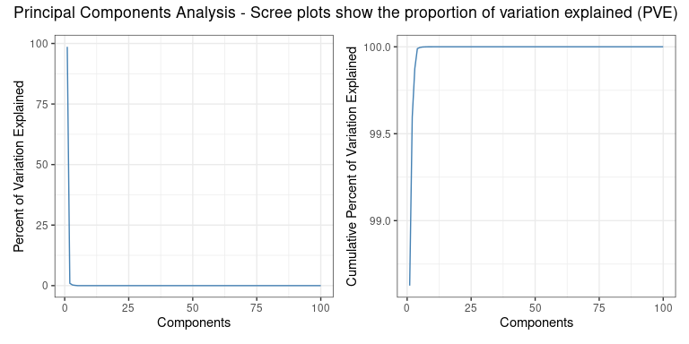

Zooming in on the “elbow” we can see that the first component explains most of the variation. With a few additional components we are nearly at 100%:

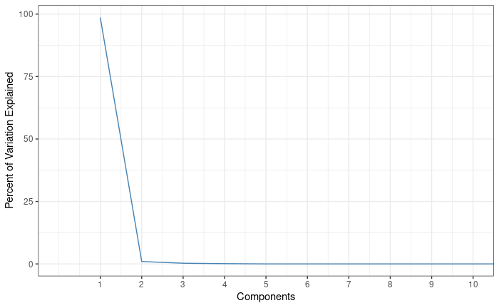

A table of the components and corresponding PVE values confirms this:

|  | PC | PVE | Cum. PVE |
| --- | --- | --- | --- |
| 1 | 1 | 98.626 | 98.626 |
| 2 | 2 | 0.970 | 99.596 |
| 3 | 3 | 0.279 | 99.875 |
| 4 | 4 | 0.114 | 99.990 |
| 5 | 5 | 0.006 | 99.996 |

Based on this analysis, the true dimensionality is much lower than the number of predictors. However, this is based on a linear combination of the data. Other nonlinear combinations of the predictors may also be useful.

# Data splitting and resampling

We will randomly split the data into a training set (75%) and test set (25%). To evaluate and tune the models we will use 10 repeats of 10-fold cross-validation (CV) on the training data. This will give a total of 100 CV estimates of the error for each candidate model. All models will then be evaluated on the held out test data. We will report the root mean squared error (RMSE) and coefficient of determination ($R^2$) on both data sets.

The data splitting is done using functions from the `rsamples` package:

```r
# Split data:
set.seed(4)
splits <- initial_split(dplyr::select(meats, -fat, -water), prop = 3/4) # 75%/25% split for the training and test sets
df_train <- training(splits)
df_test <- testing((splits))

# Create folds for 10 repeats of 10-fold cross-validation:
folds <- vfold_cv(df_train, v = 10, repeats = 10)
```

# Modeling

## Linear Regression

The first model to fit is linear regression. The only preprocessing we will do is centering and scaling of the predictors. Fitting a linear regression model on such highly correlated data may not be useful, but this will serve as a baseline to compare some other linear models to.

### Training Data

After fitting a linear regression model and evaluating using cross-validation we have the following metrics:

Linear Regression CV Results

| *R**M**S**E*<sub>*C**V*</sub> | *R*<sup>2</sup><sub>*C**V*</sub> |
| --- | --- |
| 1.613 | 0.723 |

### Test Data

After evaluating the linear regression model on the test data we have the following metrics:

Linear Regression Test Results

| *R**M**S**E*<sub>*T**e**s**t*</sub> | *R*<sup>2</sup><sub>*T**e**s**t*</sub> |
| --- | --- |
| 2.062 | 0.546 |

## Principal Components Regression

After performing PCA we found that most of the variation in the data was explained by the first few components. If we take these components and pass them in as the predictors in a linear regression model we have a principal components regression model.

Cross validation and tuning can be used to select an appropriate number of components. However in this case we will just use the first five components. Based on our PCA analysis these five components explain almost all of the variation in the data.

### Training Data

After fitting a principal components regression model and evaluating using cross-validation we have the following metrics:

PCR CV Results

| *R**M**S**E*<sub>*C**V*</sub> | *R*<sup>2</sup><sub>*C**V*</sub> |
| --- | --- |
| 1.265 | 0.829 |

### Test Data

After evaluating the principal components regression model on the test data we have the following metrics:

PCR Test Results

| *R**M**S**E*<sub>*T**e**s**t*</sub> | *R*<sup>2</sup><sub>*T**e**s**t*</sub> |
| --- | --- |
| 1.49 | 0.752 |

## Partial Least Squares

Principal components analysis is an unsupervised approach because it does not take into account the response variable (if any). An alternative supervised approach is partial least squares (PLS) which projects the data onto components which explain variance in both the predictors and the response. These components can be used as the predictors in a linear model which gives partial least squares regression.

We will use cross-validation on the training data to select an appropriate number of components to use. Ideally, the number of components should be low enough that we don’t overfit the training data.

### Training Data

The below plot shows the results of the tuning process. The RMSE quickly falls off as the number of components increases. After about 15 components are included the RMSE slowly rises again indicating overfitting may be occurring.

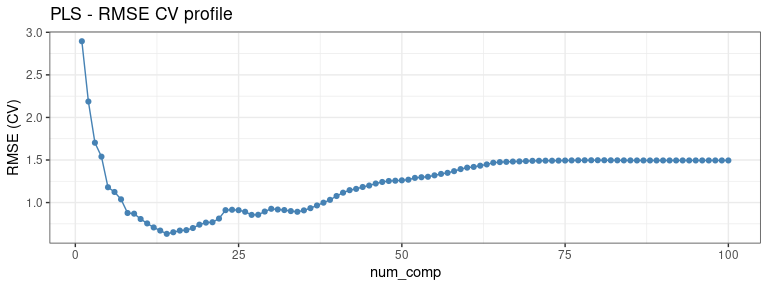

After fitting a PLS regression model and evaluating using cross-validation we have the following metrics:

PLS CV Results

| *R**M**S**E*<sub>*C**V*</sub> | *R*<sup>2</sup><sub>*C**V*</sub> |
| --- | --- |
| 0.633 | 0.956 |

### Test Data

After evaluating the PLS regression model on the test data we have the following metrics:

PLS Regression Test Results

| *R**M**S**E*<sub>*T**e**s**t*</sub> | *R*<sup>2</sup><sub>*T**e**s**t*</sub> |
| --- | --- |
| 0.705 | 0.947 |

## Ridge Regregression

Ridge regression is a penalized linear model which can often deal well with collinearity. A ridge regression model will be fit to the data and cross-validation will be used to select the penalty term ($\lambda$).

### Training Data

The below plot shows the results of the tuning process. The RMSE stays relatively constant for lower values of the penalty term. It then increases quickly as the penalty gets bigger than about 0.2:

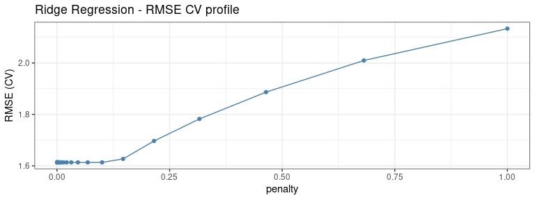

After fitting a ridge regression model and evaluating using cross-validation we have the following metrics:

Ridge Regression CV Results

| *R**M**S**E*<sub>*C**V*</sub> | *R*<sup>2</sup><sub>*C**V*</sub> |
| --- | --- |
| 1.613 | 0.723 |

### Test Data

After evaluating the ridge regression model on the test data we have the following metrics:

Ridge Regression Test Results

| *R**M**S**E*<sub>*T**e**s**t*</sub> | *R*<sup>2</sup><sub>*T**e**s**t*</sub> |
| --- | --- |
| 2.062 | 0.546 |

## Lasso

Lasso is another penalized linear model which unlike ridge regression can perform variable selection by setting some coefficients to zero. A lasso model will be fit to the data and cross-validation will be used to select the penalty term ($\lambda$).

### Training Data

The below plot shows the results of the tuning process. The RMSE is lowest for very low values of the penalty. The RMSE quickly increases as the penalty increases:

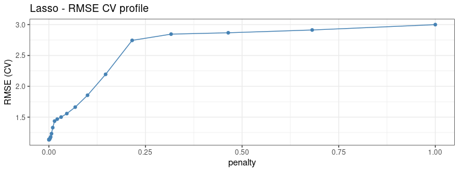

After fitting a lasso regression model and evaluating using cross-validation we have the following metrics:

Lasso CV Results

| *R**M**S**E*<sub>*C**V*</sub> | *R*<sup>2</sup><sub>*C**V*</sub> |
| --- | --- |
| 1.135 | 0.863 |

### Test Data

Fit a model using all of the training data and apply it to the test data:

After evaluating the lasso model on the test data we have the following metrics:

Lasso Test Results

| *R**M**S**E*<sub>*T**e**s**t*</sub> | *R*<sup>2</sup><sub>*T**e**s**t*</sub> |
| --- | --- |
| 1.31 | 0.818 |

## Elastic Net

The elastic net combines the ridge regression and lasso models. It can deal with highly collinear data while also performing variable selection. We will use cross-validation to tune the model to select the optimal penalty and mixture parameters.

### Training Data

The below plot shows the results of the tuning process. Including the ridge regression penalty seems to increase the error. The lowest error occurs with no ridge penalty and as much lasso penalty as possible, which means that it is essentially the same as the lasso model:

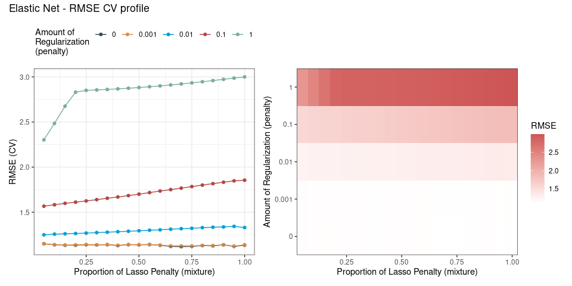

After fitting an elastic net model and evaluating using cross-validation we have the following metrics:

Elastic Net CV Results

| *R**M**S**E*<sub>*C**V*</sub> | *R*<sup>2</sup><sub>*C**V*</sub> |
| --- | --- |
| 1.119 | 0.869 |

### Test Data

After evaluating the elastic net model on the test data we have the following metrics:

Elastic Net Test Results

| *R**M**S**E*<sub>*T**e**s**t*</sub> | *R*<sup>2</sup><sub>*T**e**s**t*</sub> |
| --- | --- |
| 1.31 | 0.818 |

## Random Forest

Random forests are a non-linear tree-based method which can deal with complex and collinear data. Cross-validation will be used to select the number of variables to use at each split (`mtry`) and the number of trees.

### Training Data

The below plot shows the results of the tuning process. The number of trees used doesn’t seem to have much effect, but more appears to be better. However the RMSE decreases quickly as the number of variables used at each split increases. The models don’t seem to improve much as the number of variables used increases beyond about 30:

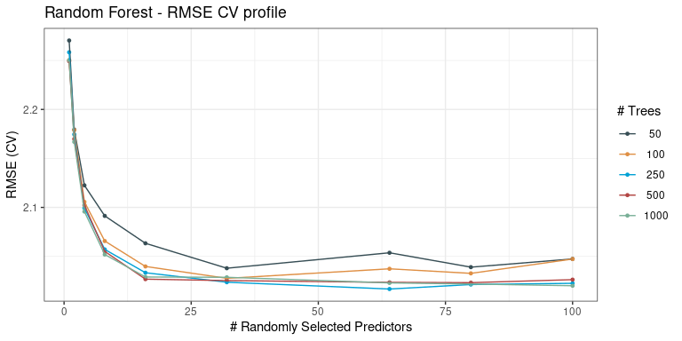

After fitting a random forest model and evaluating using cross-validation we have the following metrics:

Random Forest CV Results

| *R**M**S**E*<sub>*C**V*</sub> | *R*<sup>2</sup><sub>*C**V*</sub> |
| --- | --- |
| 2.017 | 0.561 |

### Test Data

After evaluating the random forest model on the test data we have the following metrics:

Random Forest Test Results

| *R**M**S**E*<sub>*T**e**s**t*</sub> | *R*<sup>2</sup><sub>*T**e**s**t*</sub> |
| --- | --- |
| 2.542 | 0.331 |

## Boosting

Boosted trees are another non-linear model that can handle complex and collinear data. We will implement them using the XGBoost algorithm. Cross-validation will be used to select the number of trees, learning rate and tree depth.

### Training Data

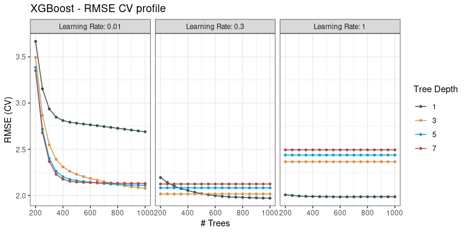

After fitting an XGBoost model and evaluating using cross-validation we have the following metrics:

XGBoost Net CV Results

| *R**M**S**E*<sub>*C**V*</sub> | *R*<sup>2</sup><sub>*C**V*</sub> |
| --- | --- |
| 1.972 | 0.567 |

### Test Data

After evaluating the XGBoost model on the test data we have the following metrics:

XGBoost Test Results

| *R**M**S**E*<sub>*T**e**s**t*</sub> | *R*<sup>2</sup><sub>*T**e**s**t*</sub> |
| --- | --- |
| 2.497 | 0.378 |

# CV and Test Results

Below is a table showing the performance of each model during cross-validation and testing. The models are ordered by their RMSE on the test data.

As expected linear regression performed the worst of the linear models.

Surprisingly, all of the linear models including linear regression performed better than the non-linear models. It’s possible that these highly flexible models overfit to the data they were trained on and had inflated errors on the held out data as a result. This is true for both the cross-validation and test errors.

| Model | Package | *R**M**S**E*<sub>*C**V*</sub> | *R**M**S**E*<sub>*T**e**s**t*</sub> | *R*<sup>2</sup><sub>*C**V*</sub> | *R*<sup>2</sup><sub>*T**e**s**t*</sub> | Parameters |
| --- | --- | --- | --- | --- | --- | --- |
| PLS | mixOmics | 0.633 | 0.705 | 0.956 | 0.947 | num_comp: 14 |
| Lasso | glmnet | 1.135 | 1.310 | 0.863 | 0.818 | penalty: 0.000215443469003188 |
| Elastic Net | glmnet | 1.119 | 1.310 | 0.869 | 0.818 | penalty: 0; mixture: 1 |
| PCR | lm | 1.265 | 1.490 | 0.829 | 0.752 | num_comp: 5 |
| Linear Regression | glmnet | 1.613 | 2.062 | 0.723 | 0.546 | NA |
| Ridge Regression | glmnet | 1.613 | 2.062 | 0.723 | 0.546 | penalty: 0 |
| XGBoost | xgboost | 1.972 | 2.497 | 0.567 | 0.378 | trees: 1000; learn_rate: 0.3; tree_depth: 1 |
| Random Forest | randomForest | 2.017 | 2.542 | 0.561 | 0.331 | trees: 250; mtry: 64 |

Below is a plot showing the distribution of the 100 CV error estimates for each optimal model. The mean CV error ($RMSE_{CV}$) and test error ($RMSE_{Test}$) are marked in blue and red respectively. The PLS model had relatively low variance in the CV error estimates which may help explain it’s superior performance on the test data:

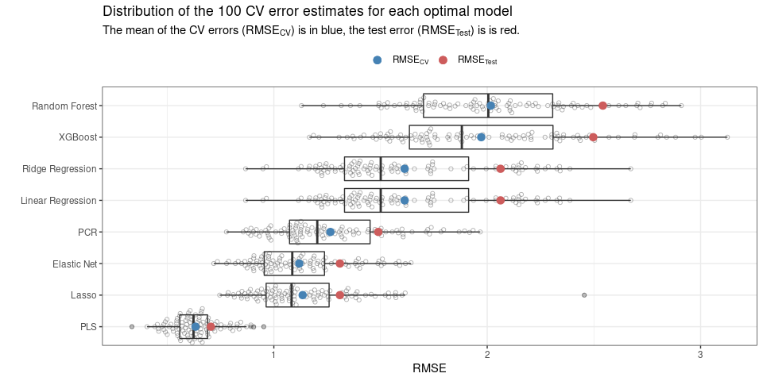

## Residuals

Below are plots showing the observed versus predicted values and residuals for each model. Even though partial least squares performed the best on the test data there appears to be a non-linear pattern in the residuals. The linear regression model also appears to exhibit a pattern of over- and under-prediction across the range of the data. For other models the residuals appear to be more randomly spread and there are no obvious patterns.

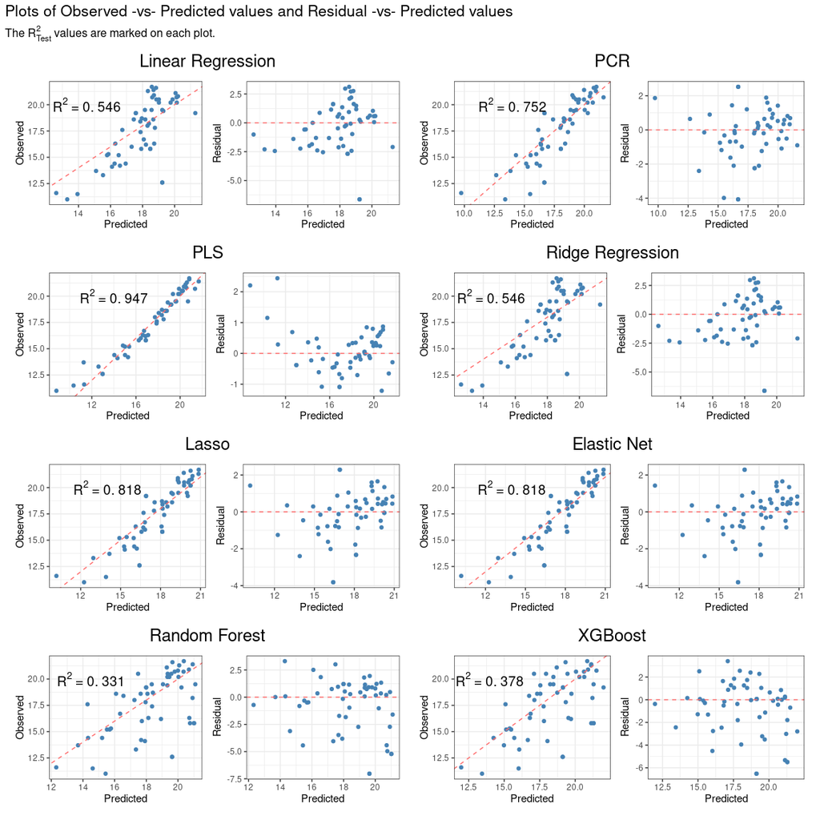

# Conclusions

We sought to predict the protein content of meat samples using IR spectroscopy data. Partial least squares regression performed the best in terms of both the cross-validated and test error. The other linear models had intermediate performance. The non-linear models performed worst.

Partial least squares is used throughout the literature on IR spectroscopy regression, including:

- The original Tecator data paper: [Borggaard and Thodberg (1992)](https://pubs.acs.org/doi/abs/10.1021/ac00029a018)
- [Goldsmith and Scheipl (2014)](https://www.sciencedirect.com/science/article/pii/S0167947313003629?casa_token=cVFvSpzRy5oAAAAA:9aaSJNbnMw5ippEJRF7G51IR18FUT3mpoOEohSipY05OSxRYRfg3-mseHinWV6leqRW8if6w)
- [Ji et al. (2015)](https://www.sciencedirect.com/science/article/pii/S0169743915000684?casa_token=fQ5r_iaEDWcAAAAA:rBKDWomBj1ZmzmQTjYPP5UDdK084nCYabITzY-gKPLgYj9Oi99ekMSgSsyD53lDzgAAzM7yC)

There are three areas that I believe would be worth further investigating:

- While the partial least squares model performed the best the residual plot showed a non-linear pattern. It would be interesting to look at ways to allow the PLS model to capture this non-linearity somehow. For example [Rosipal (2010)](https://www.researchgate.net/publication/266488967_Nonlinear_Partial_Least_Squares_An_Overview) discusses a variety of nonlinear PLS methods.
- Ridge regression is usually well-suited when there is collinearity in the data. In this case the optimal ridge regression model used a penalty of zero which corresponds to standard linear regression. Why does using a ridge penalty not improve the test error?
- Why did the non-linear models perform so poorly? Can neural networks or rule-based models do any better?